# STA 6133: Homework 1

Ricardo Cortez & Ben Graf

Due 9 Feb 2021

# 1.

Consider approximating the function $sin(x)$ by its Taylor polynomial of degree $2n − 1$:
$$p_{n}(x)=x-\frac{x^{3}}{3 !}+\frac{x^{5}}{5 !}+\cdots+(-1)^{n+1} \frac{x^{2 n-1}}{(2 n-1) !}$$

## (a)

Write an R function to compute $p_n(x)$ for $x ∈ \mathbb{R}$ and $n ∈ \mathbb{N}$.

```r
sinapprox <- function(x, n) {
  ## sin(x) approximation using Taylor polynomial of degree 2n-1
  taylor <- 0
  for (i in 1:n) {
    taylor <- taylor + (-1)^(i+1) * x^(2*i-1) / factorial(2*i-1)
  }
  return(taylor)
}
```

## (b)

Use your function to approximate $sin(x)$ for $x = \pi$ and $5\pi$, and $n =$ 10, 20, and 100. What lesson(s) can you draw from this example?

```r
sin(pi)
```

```
## [1] 1.224647e-16
```

```r
sin(5*pi)
```

```
## [1] 6.123234e-16
```

```r
sinapprox(pi,10)
```

```
## [1] -5.289183e-10
```

```r
sinapprox(pi,20)
```

```
## [1] 3.328057e-16
```

```r
sinapprox(pi,100)
```

```
## [1] 3.328057e-16
```

```r
sinapprox(5*pi,10)
```

```
## [1] -169520.9
```

```r
sinapprox(5*pi,20)
```

```
## [1] -0.2886023
```

```r
sinapprox(5*pi,100)
```

```
## [1] -4.578756e-11
```

Because the Taylor polynomial contains numerous terms with negative signs, there is a risk of subtractive cancellation. The true values of $sin(\pi)$ and $sin(5\pi)$ should be 0. Even the built-in R functions do not provide exactly 0, though their results are on the order of $10^{-16}$, so very small. We get similarly small numbers for our Taylor approximations of $sin(\pi)$, though the version with $n=10$ is not quite as small as the others. The problems really kick in with approximating $sin(5\pi)$. Because the numbers being subtracted are larger, we see major errors in the approximations. For $n=10$, the approximation is roughly $-169,000$, nowhere near 0! With $n=20$, it improves but is still around $-0.29$. Finally, with $n=100$, the approximation nears 0. The big lesson here is to beware of Taylor expansions with alternating positive and negative terms!

# 2.

On your computer, find a root fo the quadratic equation $ax^2+bx+c=0$ using the formula
$$x = \frac{-b+\sqrt{b^2-4ac}}{2a}$$

with the values $b = 1$ and $a = c= 10^{-n}$. Assess the accuracy of your answers for $n = 1, 5, 10$ by seeing how closely the equation is satisfied. Now think of a clever way to avoid subtractive cancellation and improve your answers.

## Solution:

Finding a root in a non-clever way:

```r
# create a quadratic function since we'll be testing several n's and potentially different b's
quad <- function(n,b){
  a <- 10^-n
  c <- a

  root_num_right <- sqrt(b^2-(4*a*c))
  #splitting the equations into separate terms to better understand the subtractive cancellation
  root_num <- -b +root_num_right
  root_den <- 2*a

  quad_root <- root_num/root_den
  true_root <- Re(polyroot(c(c,b,a)))[1] # only take the negative root since that's what we're dealing with


  #use Re to only take the real root of the complex number, checked them all, no imag parts.

  df <- data.frame("TrueRoot" =true_root, "QuadRoot" = quad_root)

  #calculate Relative Error
  rel_err <- abs((true_root-quad_root)/true_root)
  df$rel_err <- rel_err
  cat(paste0("Relative Error for a=",a, ", b=",b,", c=",c, ", and n=",n," is ", rel_err))

  return(df)
}

df1 = quad(1,1)
```

```
## Relative Error for a=0.1, b=1, c=0.1, and n=1 is 2.06063905221897e-15
```

```r
df2 = quad(5,1)
```

```
## Relative Error for a=1e-05, b=1, c=1e-05, and n=5 is 8.26403710463034e-08
```

```r
df3 = quad(10,1)
```

```
## Relative Error for a=1e-10, b=1, c=1e-10, and n=10 is 1
```

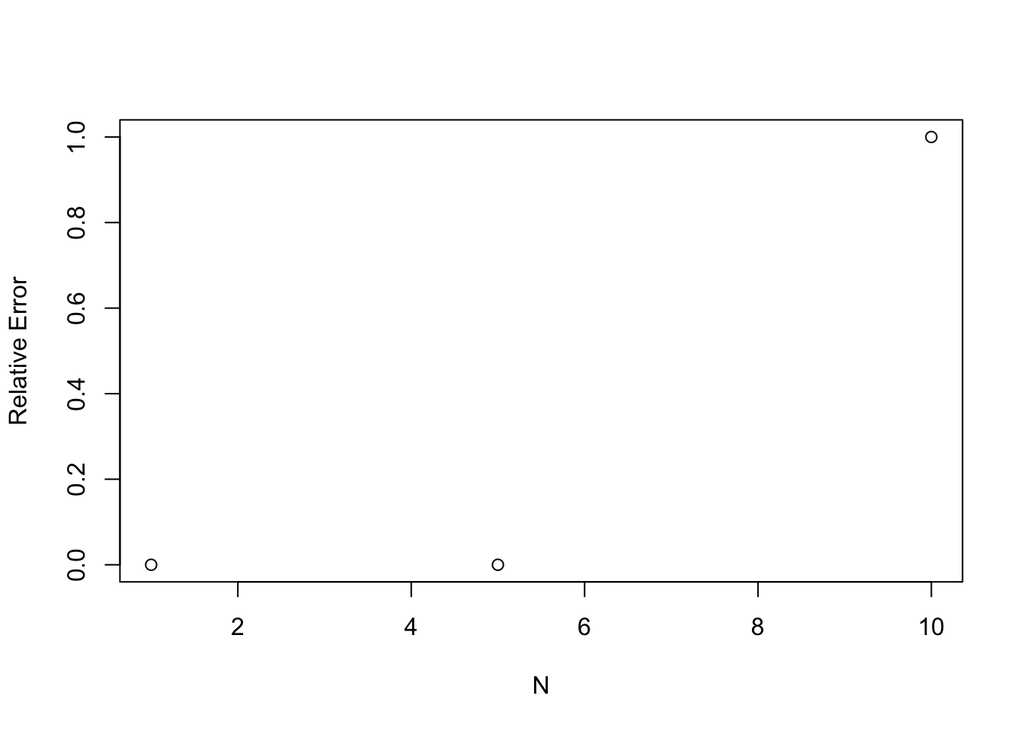

```r
plot(c(1,5,10),c(df1$rel_err,df2$rel_err,df3$rel_err), ylab = "Relative Error", xlab = "N")
```

From the plot above, we can see as n increases the relative error increases to 1, which indicates that subtractive cancellation is present. A closer observation of the individual terms (not shown) indicated that the most aggressive cancellation occurred in between the square root term and the $-b$ term. A common way of handling this type of cancellation is to use known mathematical identities to eliminate the need for subtraction between those elements. In this problem we used:
$$x^2-y^2 = (x-y)(x+y)$$

The derivation is as follows:

For simplicity, focus only on the numerator for now, the denominator can be added later.
$$\sqrt{b^2-4ac} - b$$

Let $z=\sqrt{b^2-4ac}$ and multiply by a carefully chosen version of 1:
$$\frac{(z-b)(z+b)}{z+b}=\frac{z^2-b^2}{z+b}$$

Plugging original values back in:
$$\frac{b^2-4ac-b^2}{\sqrt{b^2-4ac}+b}$$
Simplifying:
$$\frac{-4ac}{\sqrt{b^2-4ac}+b}$$
Adding back the original denominator:
$$\frac{-4ac}{2a*(\sqrt{b^2-4ac}+b)}$$
Simplify again to obtain the final equation:
$$\frac{-2c}{(\sqrt{b^2-4ac}+b)}$$

Modifying the earlier code:

```r
quad_new <- function(n,b){
  a <- 10^-n
  c <- a

  quad_root = -2*c / (sqrt(b^2 - 4*a*c) + b)
  true_root = Re(polyroot(c(c,b,a)))[1] # only take the negative root since that's what we're dealing with


  #use Re to only take the real root of the complex number, checked them all, no imag parts.

  df <- data.frame("TrueRoot" =true_root, "QuadRoot" = quad_root)

  #calculate Relative Error
  rel_err <- abs((true_root-quad_root)/true_root)
  df$rel_err <- rel_err
  cat(paste0("Relative Error for a=",a, ", b=",b,", c=",c, ", and n=",n," is ", rel_err))

  return(df)
}

df1_new <- quad_new(1,1)
```

```
## Relative Error for a=0.1, b=1, c=0.1, and n=1 is 0
```

```r
df2_new <-quad_new(5,1)
```

```
## Relative Error for a=1e-05, b=1, c=1e-05, and n=5 is 1.69406589433919e-16
```

```r
df3_new <-quad_new(10,1)
```

```
## Relative Error for a=1e-10, b=1, c=1e-10, and n=10 is 1.29246970711411e-16
```

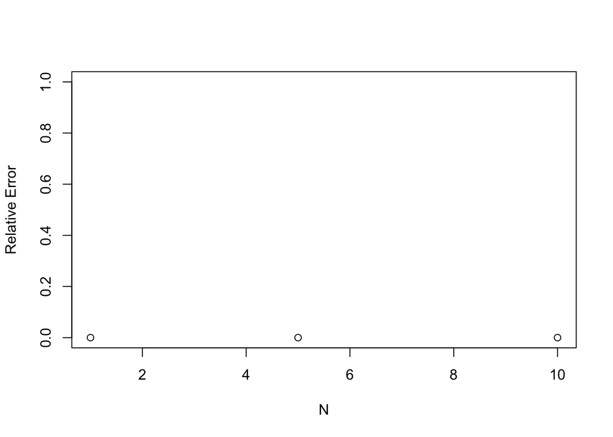

```r
plot(c(1,5,10),c(df1_new$rel_err,df2_new$rel_err,df3_new$rel_err), ylab = "Relative Error", xlab = "N",ylim = c(0,1))
```

Using the new solution provides a better estimate of the roots when subtractive cancellation is present in the original equation, it is clear to see in the plot above that the relative error stays near 0 for all N’s.

# 3.

The following data are an i.i.d. sample from the $Cauchy(\theta , 1)$ distribution $(\theta ∈ \mathbb{R})$:
$$\begin{array}
{rrr}
1.77 & -0.23 & 2.76 & 3.80 & 3.47 & 56.75 \\
-1.34 & 4.24 & -2.44 & 3.29 & 3.71 & -2.40 & \\
4.53 & -0.07 & -1.05 & -13.87 & -2.53 & -1.75 \\
0.27 & 43.21
\end{array}$$

## (a)

Plot the log–likelihood function. Then find the MLE of $\theta$ using Newton’s method. Try all the following starting values: −11, −1, 0, 1.5, 4, 4.7, 7, 38. Discuss your results. Is the sample mean a good starting point?

The density for $Cauchy(\theta , \sigma)$ is:
$$f(x \mid \theta, \sigma)=\frac{1}{\pi \sigma} \frac{1}{1+\left(\frac{x-\theta}{\sigma}\right)^{2}}$$
Because $\sigma=1$, we get:
$$f(x \mid \theta, \sigma)=\frac{1}{\pi} \frac{1}{1+\left(x-\theta\right)^{2}} \quad , \quad -\infty < \theta < \infty \quad , \quad -\infty < x < \infty$$
The joint density is then:
$$f(\textbf{x} \mid \theta, 1)=\prod_{i=1}^{n} \frac{1}{\pi} \frac{1}{1+(x_i-\theta)^{2}}=\pi^{-n} \prod_{i=1}^{n} \frac{1}{1+(x_{i}-\theta)^{2}}$$
The log-likelihood is then:
$$l(\theta)=-n \ln \pi-\sum_{i=1}^{n} \ln \left(1+\left(x_{i}-\theta\right)^{2}\right)$$
Its first derivative is:
$$l^{\prime}(\theta)=\sum_{i=1}^{n} \frac{2\left(x_{i}-\theta\right)}{1+\left(x_{i}-\theta\right)^{2}}$$
And its second derivative is:
$$l^{\prime \prime}(\theta)=\sum_{i=1}^{n} \frac{\left(1+\left(x_{i}-\theta\right)^{2}\right)(-2)-2\left(x_{i}-\theta\right)\left(-2\left(x_{i}-\theta\right)\right)}{\left(1+\left(x_{i}-\theta\right)^{2}\right)^{2}}$$
$$=\sum_{i=1}^{n} \frac{-2\left(1+\left(x_{i}-\theta\right)^{2}\right)+4\left(x_{i}-\theta\right)^{2}}{\left(1+\left(x_{i}-\theta\right)^{2}\right)^{2}}=\sum \frac{2\left(-1+\left(x_{i}-\theta\right)^{2}\right)}{\left(1+\left(x_{i}-\theta\right)^{2}\right)^{2}}$$
The corresponding R functions are:

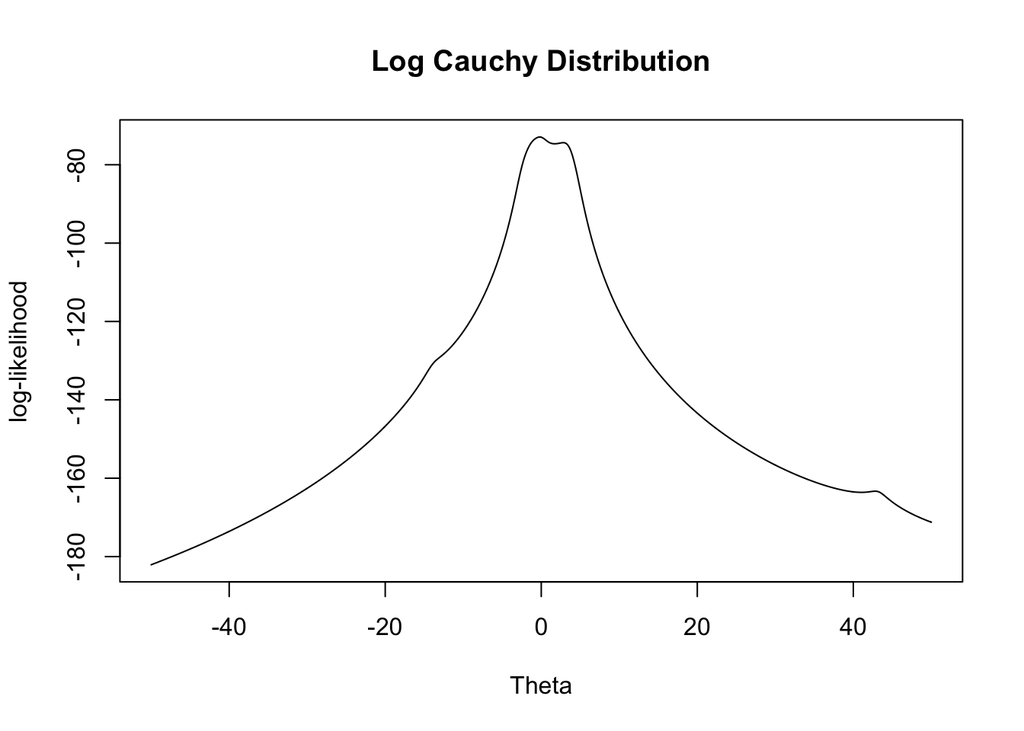

```r
#Import the data
data <- c(1.77, -0.23, 2.76, 3.80, 3.47, 56.75, -1.34, 4.24, -2.44, 3.29,
          3.71, -2.40, 4.53, -0.07, -1.05, -13.87, -2.53, -1.75, 0.27, 43.21)

n <- length(data)

#log likelihood cauchy function
log_cauchy <- function(theta){
  return(-n*log(pi)-sum(log(1+(data-theta)^2)))
}
#first derivative of the log-likelihood
log_cauchy_prime <- function(theta){
return(sum(2*(data-theta)/(1+(data-theta)^2)))
}

#second derivative of the log-likelihood
log_cauchy_2prime <- function(theta){
  return(sum(2*(-1+(data-theta)^2) / (1+(data-theta)^2)^2))
}

#function for log-cauchy and log-cauchy prime
cauchy <- function(theta){
  return(c(log_cauchy(theta),
           log_cauchy_prime(theta)))
}
#function for log-cauchy prime and 2nd prime of log-cauchy
cauchy_primes <- function(theta){
  return(c(log_cauchy_prime(theta),log_cauchy_2prime(theta)))
}

theta_list <- seq(-50,50,.1)
values <- sapply(theta_list, cauchy)

log_cauchy_values <- values[1,]
log_cauchy_prime_values <- values[2,]

plot(theta_list,log_cauchy_values, type = "l", main = "Log Cauchy Distribution",xlab = "Theta", ylab = "log-likelihood")
```

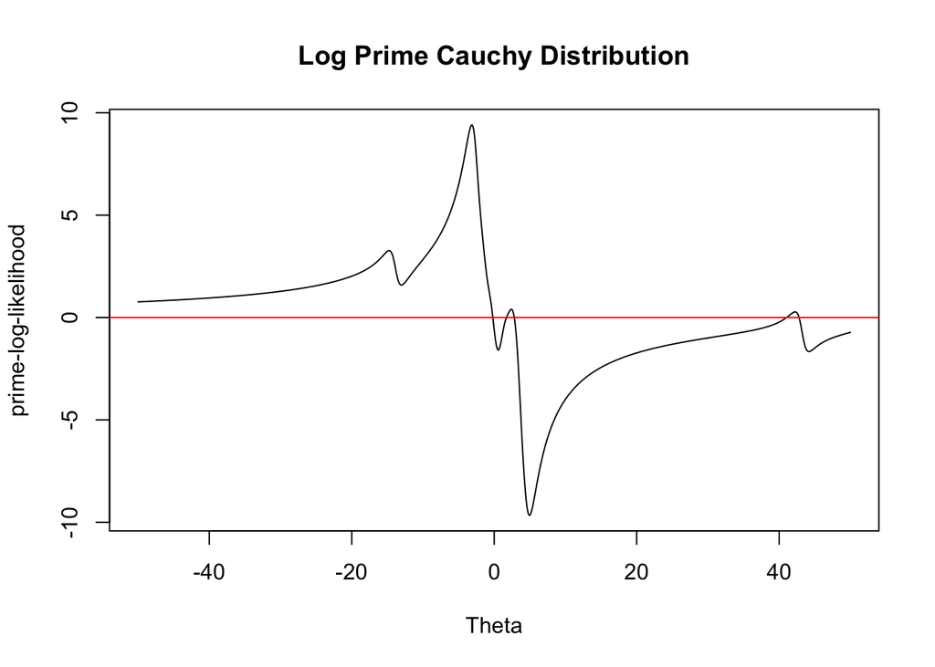

```r
plot(theta_list,log_cauchy_prime_values, type = "l", main = "Log Prime Cauchy Distribution", xlab = "Theta", ylab = "prime-log-likelihood")
abline(h = 0, col = "red")
```

```r
# Newton's Method function provided by Dr. DeOliveira
newtonraphson <- function(ftn, x0, tol = 1e-9, max.iter = 100) {
  ## Newton_Raphson algorithm for solving ftn(x)[1] == 0
  ## It is assumed that ftn is a function of a single variable that returns
  ## the function value and its first derivative as a vector of length 2.
  ## x0 is the initial guess of the root.
  ## The algorithm terminates when the function value is within distance tol of 0,
  ## or the number of iterations exceeds max.iter, whichever happens first
  # initialise
  x <- x0
  fx <- ftn(x)
  iter <-  0
  # continue iterating until stopping conditions are met
  while ((abs(fx[1]) > tol) & (iter < max.iter)) {
    x <- x - fx[1]/fx[2]
    fx <- ftn(x)
    iter <- iter+1
    #cat("At iteration", iter, "value of x is:", x, "\n")
  }
  # output depends on success of algorithm
  if (abs(fx[1]) > tol) {
    #cat("Algorithm failed to converge\n")
    return(NULL)
  } else {
    #cat("Algorithm converged\n")
    return(c(root = x, f.val = fx[1]))
  }
}
```

We test using the recommended starting values:

```r
mle_values <- roots <- test_values <- c(-11,-1,0,1.5,4,4.7,7,38, mean(data))

for(i in 0:length(test_values)){
  root <- newtonraphson(cauchy_primes,test_values[i])[1]
  roots[i] <- root
  mle_values[i] <- log_cauchy(root)
}
roots
```

```
## [1] -5.381711e+10 -1.922866e-01 -1.922866e-01  1.713587e+00  2.817472e+00
## [6] -1.922866e-01  4.104085e+01  4.279538e+01  5.487662e+01
```

```r
 ### max value is at -1
cat(paste0("The maximum log-likelihood value of ", test_values[which.max(mle_values)], " occurs when theta = ", roots[which.max(mle_values)]))
```

```
## The maximum log-likelihood value of -1 occurs when theta = -0.192286613229646
```

$\boldsymbol{\hat{\theta}_{MLE} = -0.1923}$.

Utilizing different starting points resulted in getting several different root values, which, given the execution pattern of the Newton-Raphson algorithm and the log-prime Cauchy distribution plot above, would be expected. Using the sample mean for a Cauchy distribution is not advantageous because the Cauchy distribution does not have a population mean. In fact, the sample mean as a starting point does *not* lead to the MLE.

## (b)

Apply the bisection method with bracketing interval [−1, 1]. Comment on the result. Now run the bisection method with another bracketing interval that makes the algoritm converge to the ‘wrong root’, i.e., to a local maximum.

```r
# Bisection Method function provided by Dr. DeOliveira
bisection <- function(f, x1, x2, maxit = 1000, tol = 1e-7, stop.fval = TRUE) {
  # it uses absolute error as stopping criterion when stop.fval = FALSE
  f1 <- f(x1)
  if (abs(f1) < tol)
    return(x1)
  f2 <- f(x2)
  if (abs(f2) < tol)
    return(x2)
  if (f1 * f2 > 0)
    stop("f has equal sign at endpoints of initial interval")
  if (f1 > 0) { # swap x1 and x2
    tmp <- x1 ; x1 <- x2 ; x2 <- tmp
  }
  n <- 0 # counter
  x <- x1
  repeat {
    n <- n + 1
    x.mid <- (x1 + x2) / 2
    f.mid <- f(x.mid)
    if(stop.fval == TRUE) {
      if(abs(f.mid) < tol | n == maxit)
        break }
    else if(abs(x.mid - x) < tol | n == maxit)
      break
    if(f.mid<0){ x1 <- x.mid ; x <- x1}
    else { x2 <- x.mid ; x <- x2 }
  }
  return(list(root = x.mid, f = f.mid, iter = n))
}

bisection(log_cauchy_prime, -1, 1, tol = 1e-9)
```

```
## $root
## [1] -0.1922866
##
## $f
## [1] 5.166203e-10
##
## $iter
## [1] 31
```

The Bisection took 31 iterations to converge with the given interval. The Newton-Raphson at worst took about the same number of iterations but often took fewer than 10 iterations. Below we see a poor choice of bracketing inveral results in converging to a local maximum.

```r
bisection(log_cauchy_prime, 1, 2, tol = 1e-9)   #This bracket converges to a local maximum, not the global
```

```
## $root
## [1] 1.713587
##
## $f
## [1] 3.384803e-10
##
## $iter
## [1] 29
```

## (c)

Apply a fixed–point iteration with starting value −1 and scaling choices $\alpha =$ 1, 0.64, 0.25. Discuss your results.

```r
fixedpoint <- function(f, starting, alpha, maxit = 1000, tol = 1e-9) {
  # g(x) = x + alpha * f(x)
  x <- starting
  fx <- f(starting)
  iter <- 0
  while ((abs(fx) > tol) & (iter < maxit))  {
    x <- x + alpha*fx
    fx <- f(x)
    iter <- iter + 1
    #cat("At iteration", iter, "value of x is:", x, "\n")
  }
  if (abs(fx) > tol) {
    cat("Algorithm failed to converge\n")
    return(NULL)
  } else {
    cat("Algorithm converged\n")
    return(list(root = x, f.val = fx, iter = iter))
  }
}

fixedpoint(log_cauchy_prime, -1, 1)
```

```
## Algorithm failed to converge
```

```r
fixedpoint(log_cauchy_prime, -1, 0.64)
```

```
## Algorithm converged
```

```
## $root
## [1] -0.1922866
##
## $f.val
## [1] 9.973122e-10
##
## $iter
## [1] 700
```

```r
fixedpoint(log_cauchy_prime, -1, 0.25)
```

```
## Algorithm converged
```

```
## $root
## [1] -0.1922866
##
## $f.val
## [1] 4.31729e-10
##
## $iter
## [1] 16
```

```r
fixedpoint(log_cauchy_prime, -1, 0.2)
```

```
## Algorithm converged
```

```
## $root
## [1] -0.1922866
##
## $f.val
## [1] 5.361135e-10
##
## $iter
## [1] 24
```

For an $\alpha$ of 1, the fixed-point algorithm failed to converge. Reducing $\alpha$ to 0.64 does achieve convergence, but it takes 700 iterations. Further reducing $\alpha$ to 0.25 takes a mere 16 iterations! Reducing $\alpha$ any lower with the same starting point begins increasing the number of iterations again.

# 4.

There were 46 crude oil spills of at least 1000 barrels from tankers in U.S. waters during 1974–1999. The web page http://www.stat.colostate.edu/computationalstatistics/ contains the following data:  
$N_i =$ number of spills in year $i$;  
$b_{i1} =$ amount of oil shipped through U.S. waters from import/export shipments in year $i$ (in billions of barrels [Bbbl]);  
$b_{i2} =$ amount of oil shipped through U.S. waters U.S. from domestic shipments in year $i$.  
Suppose we use the Poisson process model that assumes $N_i | b_{i1}, b_{i2} ∼ Poisson(\alpha_1b_{i1} + \alpha_2b_{i2})$. The volume of oil shipped is a measure of spill risk, so $\alpha_1$ and $\alpha_2$ represent the rates of spill occurrences per Bbbl during import/export and domestic shipments, respectively.

## (a)

Derive Newton’s iterative algorithm for finding the MLE of $\boldsymbol{\alpha} = (\alpha_1, \alpha_2)$, and write an R function to implement this algorithm. Then run this iterative algorithm to compute the MLE of $\boldsymbol{\alpha}$ based on the above dataset.

The joint density of $\textbf{N}$ is:
$$f(\textbf{N} \mid \boldsymbol{\alpha})=\prod_{i=1}^{n} e^{-\left(\alpha_1 b_{i1}+\alpha_{2} b_{i2}\right)} \frac{\left(\alpha_{1} b_{i1}+\alpha_{2} b_{i2}\right)^{N_{i}}}{N_{i} !}$$
The log-likelihood of $\boldsymbol{\alpha}$ is therefore:
$$l(\boldsymbol{\alpha}) = \sum_{i=1}^{n} \bigl( -\left(a_{i} b_{i1} + \alpha_{2} b_{i 2}\right) + N_i \ln (\alpha_{1} b_{i1} + \alpha_{2} b_{i2}) - \ln N_{i}! \bigr)$$
Its first derivatives are:
$$\frac{\partial l}{\partial \alpha_{1}}=\sum_{i=1}^{n}\left(-b_{i1}+N_{i} \frac{b_{i1}}{\alpha_{1} b_{i 1}+\alpha_{2} b_{i 2}}\right)$$
$$\frac{\partial l}{\partial \alpha_{2}}=\sum_{i=1}^{n}\left(-b_{i2}+N_{i} \frac{b_{i2}}{\alpha_{1} b_{i 1}+\alpha_{2} b_{i 2}}\right)$$
The gradient is defined as:
$$\nabla l(\boldsymbol{\alpha})=\left(\begin{array}{l}
\frac{\partial l}{\partial \alpha_{1}} \\
\frac{\partial l}{\partial \alpha_{2}}
\end{array}\right)$$
The second derivatives are:
$$\frac{\partial^{2} l}{\partial \alpha_{1}^2} =\sum_{i=1}^{n} \frac{-N_{i} b_{i1}^2}{\left(\alpha_{1} b_{i1}+\alpha_{2} b_{i2}\right)^{2}}$$
$$\frac{\partial^{2} l}{\partial \alpha_{1} \partial \alpha_{2}}=\frac{\partial^{2} l}{\partial \alpha_{2} \partial \alpha_{1}}=\sum_{i=1}^{n} \frac{-N_{i} b_{i1} b_{i 2}}{\left(\alpha_{1} b_{i1}+\alpha_{2} b_{i2}\right)^{2}}$$
$$\frac{\partial^{2} l}{\partial \alpha_{2}^2} =\sum_{i=1}^{n} \frac{-N_{i} b_{i2}^2}{\left(\alpha_{1} b_{i1}+\alpha_{2} b_{i2}\right)^{2}}$$
The Hessian matrix is defined as:
$$H_{l}(\boldsymbol{\alpha})=\left[\begin{array}{cc}
\frac{\partial^{2} l}{\partial \alpha_{1}^{2}} & \frac{\partial^{2} l}{\partial \alpha_{1} \partial \alpha_{2}} \\
\frac{\partial^{2} l}{\partial \alpha_{2} \alpha_{1}} & \frac{\partial^{2} l}{\partial \alpha_{2}^{2}}
\end{array}\right]$$
Newton’s iterative algorithm is therefore defined as:
$$\boldsymbol{\alpha}_{n+1}=\boldsymbol{\alpha}_{n}-\left(H_{l}\left(\boldsymbol\alpha_{n}\right)\right)^{-1} \nabla l\left(\boldsymbol{\alpha}_{n}\right), n=0,1,2, \ldots$$
The R functions to implement this are as follows:

```r
setwd("/Users/Ben/Library/Mobile Documents/com~apple~CloudDocs/Documents/UTSA Master's/Semester 4/STA 6133 Simulation & Statistical Computing/Homework/Homework 1/")
#readLines("oilspills.dat")
oil <- read.table("oilspills.dat", header = TRUE)

# Log-likelihood function for Poisson
llpois <- function(alphas, bs, N) {
  ## alphas should be 1x2, bs should be 2xn, N should be 1xn
  term <- alphas %*% bs
  return(sum(-term + N*log(term) - log(factorial(N))))
}

# Gradient of log-likelihood for Poisson
gradpois <- function(alphas, bs, N) {
  ## alphas should be 1x2, bs should be 2xn, N should be 1xn
  term <- alphas %*% bs
  drv1 <- sum(-bs[1,] + N*bs[1,]/term)
  drv2 <- sum(-bs[2,] + N*bs[2,]/term)
  return(as.matrix(c(drv1,drv2)))
}

# Hessian of log-likelihood for Poisson
hesspois <- function(alphas, bs, N) {
  ## alphas should be 1x2, bs should be 2xn, N should be 1xn
  term <- alphas %*% bs
  drv11 <- sum(-N * (bs[1,])^2 / (term^2))
  drv12 <- sum(-N * bs[1,] * bs[2,] / (term^2))
  drv22 <- sum(-N * (bs[2,])^2 / (term^2))
  return(matrix(c(drv11,drv12, drv12,drv22), nrow = 2, ncol = 2, byrow = TRUE))
}

# Newton's Method adapted for this problem
newtonmulti <- function(grad, hess, x0, data1, data2, tol = 1e-9, max.iter = 100) {
  ## Newton_Raphson algorithm for solving grad == 0.
  ## x0 is the initial guess of the roots.
  ## The algorithm terminates when the function value is within distance tol of 0,
  ## or the number of iterations exceeds max.iter, whichever happens first.

  # initialise
  x <- x0
  fx <- grad(x, data1, data2)
  iter <-  0
  # continue iterating until stopping conditions are met
  while (((abs(fx[1]) > tol) | (abs(fx[2]) > tol)) & (iter < max.iter)) {
    x <- x - t(solve(hess(x,data1,data2)) %*% grad(x,data1,data2))
    fx <- grad(x, data1, data2)
    iter <- iter+1
    cat("At iteration", iter, "value of x is:", x, "and f is:", fx, "\n")
  }

  # output depends on success of algorithm
  if ((abs(fx[1]) > tol) | (abs(fx[2]) > tol)) {
    cat("Algorithm failed to converge\n")
    return(NULL)
  } else {
    cat("Algorithm converged\n")
    return(c(root = x, f.val = fx))
  }
}
```

Testing the function with a variety of starting points yields:

```r
# Run Newton's Method
testalphas <- t(as.matrix(c(1,1)))
bs <- t(as.matrix(oil[,3:4]))
N <- oil[,2]
res <- newtonmulti(gradpois, hesspois, testalphas, bs, N)
```

```
## At iteration 1 value of x is: 1.090831 0.9426757 and f is: 0.05893873 0.01547945
## At iteration 2 value of x is: 1.097128 0.9375748 and f is: 0.0002198173 5.441683e-05
## At iteration 3 value of x is: 1.097153 0.9375546 and f is: 3.178962e-09 7.871014e-10
## At iteration 4 value of x is: 1.097153 0.9375546 and f is: -1.110223e-16 4.440892e-16
## Algorithm converged
```

```r
llpois(res[1:2], bs, N)
```

```
## [1] -48.02716
```

```r
newtonmulti(gradpois, hesspois, t(as.matrix(c(0.5,0.5))), bs, N)
```

```
## At iteration 1 value of x is: 0.7727078 0.7356689 and f is: 9.934929 6.243195
## At iteration 2 value of x is: 1.001826 0.8965661 and f is: 2.117605 1.293061
## At iteration 3 value of x is: 1.08905 0.9364765 and f is: 0.1456226 0.08299321
## At iteration 4 value of x is: 1.097096 0.9375682 and f is: 0.0008103152 0.0003982823
## At iteration 5 value of x is: 1.097153 0.9375546 and f is: 2.760745e-08 1.037014e-08
## At iteration 6 value of x is: 1.097153 0.9375546 and f is: -1.110223e-16 4.440892e-16
## Algorithm converged
```

```
##         root1         root2        f.val1        f.val2
##  1.097153e+00  9.375546e-01 -1.110223e-16  4.440892e-16
```

```r
newtonmulti(gradpois, hesspois, t(as.matrix(c(0.1,0.5))), bs, N)
```

```
## At iteration 1 value of x is: 0.2055593 0.8153307 and f is: 45.0863 20.6025
## At iteration 2 value of x is: 0.4085579 1.114891 and f is: 17.60121 7.294911
## At iteration 3 value of x is: 0.7192223 1.176014 and f is: 5.309933 1.781389
## At iteration 4 value of x is: 0.9984792 1.019079 and f is: 0.9585817 0.24154
## At iteration 5 value of x is: 1.091235 0.9425422 and f is: 0.05339925 0.012897
## At iteration 6 value of x is: 1.097132 0.9375719 and f is: 0.0001887155 4.666506e-05
## At iteration 7 value of x is: 1.097153 0.9375546 and f is: 2.344399e-09 5.804666e-10
## At iteration 8 value of x is: 1.097153 0.9375546 and f is: 9.436896e-16 8.881784e-16
## Algorithm converged
```

```
##        root1        root2       f.val1       f.val2
## 1.097153e+00 9.375546e-01 9.436896e-16 8.881784e-16
```

```r
newtonmulti(gradpois, hesspois, t(as.matrix(c(0.8,0.5))), bs, N)
```

```
## At iteration 1 value of x is: 1.020556 0.7477629 and f is: 3.400149 2.595636
## At iteration 2 value of x is: 1.093548 0.9057989 and f is: 0.3543095 0.2991098
## At iteration 3 value of x is: 1.097232 0.9368358 and f is: 0.005220441 0.005188247
## At iteration 4 value of x is: 1.097153 0.9375543 and f is: 1.525131e-06 1.74987e-06
## At iteration 5 value of x is: 1.097153 0.9375546 and f is: 1.797451e-13 2.146616e-13
## Algorithm converged
```

```
##        root1        root2       f.val1       f.val2
## 1.097153e+00 9.375546e-01 1.797451e-13 2.146616e-13
```

```r
newtonmulti(gradpois, hesspois, t(as.matrix(c(2,0.5))), bs, N)
```

```
## At iteration 1 value of x is: 0.5397918 1.334004 and f is: 8.537706 2.489554
## At iteration 2 value of x is: 0.8855011 1.121394 and f is: 2.126835 0.4806032
## At iteration 3 value of x is: 1.070158 0.9606329 and f is: 0.243707 0.05690754
## At iteration 4 value of x is: 1.096722 0.9379148 and f is: 0.003902619 0.0009604976
## At iteration 5 value of x is: 1.097152 0.9375547 and f is: 1.004578e-06 2.487083e-07
## At iteration 6 value of x is: 1.097153 0.9375546 and f is: 6.544765e-14 1.626477e-14
## Algorithm converged
```

```
##        root1        root2       f.val1       f.val2
## 1.097153e+00 9.375546e-01 6.544765e-14 1.626477e-14
```

```r
newtonmulti(gradpois, hesspois, t(as.matrix(c(2,2))), bs, N)
```

```
## At iteration 1 value of x is: 0.3633246 -0.2292973 and f is: 19.33009 -145.1933
## At iteration 2 value of x is: 0.6813456 -0.430406 and f is: 3.548708 -76.50709
## At iteration 3 value of x is: 1.20365 -0.7617812 and f is: -3.752098 -41.64224
## At iteration 4 value of x is: 1.912676 -1.215075 and f is: -6.239723 -23.16762
## At iteration 5 value of x is: 2.584328 -1.653179 and f is: -5.39579 -12.03947
## At iteration 6 value of x is: 2.924771 -1.888807 and f is: -2.417535 -4.272862
## At iteration 7 value of x is: 2.998046 -1.947498 and f is: -0.3045471 -0.5066411
## At iteration 8 value of x is: 3.004649 -1.953398 and f is: -0.003872094 -0.006456701
## At iteration 9 value of x is: 3.004737 -1.953477 and f is: -6.418283e-07 -1.071488e-06
## At iteration 10 value of x is: 3.004737 -1.953477 and f is: 4.463097e-14 6.028511e-14
## Algorithm converged
```

```
##         root1         root2        f.val1        f.val2
##  3.004737e+00 -1.953477e+00  4.463097e-14  6.028511e-14
```

All but one of these starting points converge to the same root, $\boldsymbol{\hat\alpha_{MLE} = (1.0972, 0.9376)}$. (The final starting point sees $\alpha_2$ converge to a negative number, which seems inappropriate given the Poisson distribution.) Plotting the log-likelihood for a range of $\alpha$s (not shown) to check that we are converging to a maximum reveals that the maximum does appear to be where both $\alpha$s are between 0 and 2, with the highest-valued sample point being $(1.1,0.9)$, so our root appears to be correct!

## (b)

Derive the Fisher scoring iterative algorithm for finding the MLE of $\boldsymbol\alpha$, and write an R function to implement this algorithm. Then run this iterative algorithm to compute the MLE of $\boldsymbol\alpha$ based on the above dataset.

The terms of the Fisher Information matrix are:
$$(I(\boldsymbol{\alpha}))_{ij}=-E_{\boldsymbol\alpha}\left[\frac{\partial^{2}}{\partial \alpha_{i} \partial \alpha_{j}} l(\boldsymbol{\alpha}, \textbf{N})\right]$$
The first term can therefore be calculated to be:
$$(I(\boldsymbol\alpha))_{11} = E\left[\frac{\partial^{2} l}{\partial \alpha_{1}^{2}}\right] = E\left[\sum_{i=1}^{n} \frac{N_{i} b_{i1}^{2}}{\left(\alpha_{1} b_{i1}+\alpha_{2} b_{i2}\right)^{2}}\right] = \sum_{i=1}^{n} \frac{b_{i 1}{ }^{2} E\left[N_{i}\right]}{\left(\alpha_{1} b_{i 1}+\alpha_{2} b_{i2}\right)^{2}}$$
Because $E[N_{i}]$ is the Poisson parameter, we get:
$$=\sum_{i=1}^{n} \frac{b_{i1}^{2}\left(\alpha_{1} b_{i1}+\alpha_{2} b_{i2}\right)}{\left(\alpha_{1} b_{i 1}+\alpha_{2} b_{i 2}\right)^{2}} = \sum_{i=1}^{n} \frac{b_{i1}^2}{\alpha_{1} b_{i1}+\alpha_{2} b_{i 2}}$$
Similarly:
$$(I(\boldsymbol\alpha))_{12} = (I(\boldsymbol\alpha))_{21} = \sum_{i=1}^{n} \frac{b_{i 1} b_{i 2}}{\alpha_{1} b_{i 1}+\alpha_{2} b_{i 2}}$$
$$(I(\boldsymbol\alpha))_{22} = \sum_{i=1}^{n} \frac{b_{i2}^2}{\alpha_{1} b_{i1}+\alpha_{2} b_{i 2}}$$
Running Newton’s algorithm for the same set of starting points yields:

```r
# Fisher Information of log-likelihood for Poisson
ipois <- function(alphas, bs, N) {
  ## alphas should be 1x2, bs should be 2xn, N should be 1xn
  term <- alphas %*% bs
  drv11 <- -sum((bs[1,])^2 / term)
  drv12 <- -sum(bs[1,] * bs[2,] / term)
  drv22 <- -sum((bs[2,])^2 / term)
  return(matrix(c(drv11,drv12, drv12,drv22), nrow = 2, ncol = 2, byrow = TRUE))
}

# Run Newton's Method
res2 <- newtonmulti(gradpois, ipois, testalphas, bs, N)
```

```
## At iteration 1 value of x is: 1.117785 0.9062845 and f is: -0.05712725 0.07045913
## At iteration 2 value of x is: 1.090702 0.9473314 and f is: 0.01871967 -0.02155272
## At iteration 3 value of x is: 1.099195 0.9344591 and f is: -0.005841277 0.006871037
## At iteration 4 value of x is: 1.096508 0.9385308 and f is: 0.001850667 -0.00216218
## At iteration 5 value of x is: 1.097356 0.9372463 and f is: -0.0005835163 0.0006831982
## At iteration 6 value of x is: 1.097088 0.9376519 and f is: 0.000184263 -0.0002155948
## At iteration 7 value of x is: 1.097173 0.9375239 and f is: -5.815872e-05 6.806245e-05
## At iteration 8 value of x is: 1.097146 0.9375643 and f is: 1.835935e-05 -2.148428e-05
## At iteration 9 value of x is: 1.097155 0.9375515 and f is: -5.795342e-06 6.781905e-06
## At iteration 10 value of x is: 1.097152 0.9375556 and f is: 1.829394e-06 -2.140805e-06
## At iteration 11 value of x is: 1.097153 0.9375543 and f is: -5.774754e-07 6.757782e-07
## At iteration 12 value of x is: 1.097152 0.9375547 and f is: 1.822889e-07 -2.133196e-07
## At iteration 13 value of x is: 1.097153 0.9375546 and f is: -5.754227e-08 6.733757e-08
## At iteration 14 value of x is: 1.097153 0.9375546 and f is: 1.816409e-08 -2.125613e-08
## At iteration 15 value of x is: 1.097153 0.9375546 and f is: -5.733772e-09 6.709819e-09
## At iteration 16 value of x is: 1.097153 0.9375546 and f is: 1.809952e-09 -2.118057e-09
## At iteration 17 value of x is: 1.097153 0.9375546 and f is: -5.713394e-10 6.685968e-10
## Algorithm converged
```

```r
llpois(res2[1:2], bs, N)
```

```
## [1] -48.02716
```

```r
newtonmulti(gradpois, ipois, t(as.matrix(c(0.5,0.5))), bs, N)
```

```
## At iteration 1 value of x is: 1.117785 0.9062845 and f is: -0.05712725 0.07045913
## At iteration 2 value of x is: 1.090702 0.9473314 and f is: 0.01871967 -0.02155272
## At iteration 3 value of x is: 1.099195 0.9344591 and f is: -0.005841277 0.006871037
## At iteration 4 value of x is: 1.096508 0.9385308 and f is: 0.001850667 -0.00216218
## At iteration 5 value of x is: 1.097356 0.9372463 and f is: -0.0005835163 0.0006831982
## At iteration 6 value of x is: 1.097088 0.9376519 and f is: 0.000184263 -0.0002155948
## At iteration 7 value of x is: 1.097173 0.9375239 and f is: -5.815872e-05 6.806245e-05
## At iteration 8 value of x is: 1.097146 0.9375643 and f is: 1.835935e-05 -2.148428e-05
## At iteration 9 value of x is: 1.097155 0.9375515 and f is: -5.795342e-06 6.781905e-06
## At iteration 10 value of x is: 1.097152 0.9375556 and f is: 1.829394e-06 -2.140805e-06
## At iteration 11 value of x is: 1.097153 0.9375543 and f is: -5.774754e-07 6.757782e-07
## At iteration 12 value of x is: 1.097152 0.9375547 and f is: 1.822889e-07 -2.133196e-07
## At iteration 13 value of x is: 1.097153 0.9375546 and f is: -5.754227e-08 6.733757e-08
## At iteration 14 value of x is: 1.097153 0.9375546 and f is: 1.816409e-08 -2.125613e-08
## At iteration 15 value of x is: 1.097153 0.9375546 and f is: -5.733772e-09 6.709819e-09
## At iteration 16 value of x is: 1.097153 0.9375546 and f is: 1.809952e-09 -2.118057e-09
## At iteration 17 value of x is: 1.097153 0.9375546 and f is: -5.713394e-10 6.685968e-10
## Algorithm converged
```

```
##         root1         root2        f.val1        f.val2
##  1.097153e+00  9.375546e-01 -5.713394e-10  6.685968e-10
```

```r
newtonmulti(gradpois, ipois, t(as.matrix(c(0.1,0.5))), bs, N)
```

```
## At iteration 1 value of x is: 1.417701 0.451749 and f is: -0.4419727 1.38702
## At iteration 2 value of x is: 1.009561 1.070303 and f is: 0.2901992 -0.2737298
## At iteration 3 value of x is: 1.125967 0.8938844 and f is: -0.07863297 0.09904877
## At iteration 4 value of x is: 1.088177 0.9511568 and f is: 0.02615637 -0.02992437
## At iteration 5 value of x is: 1.099998 0.9332428 and f is: -0.008125141 0.009576966
## At iteration 6 value of x is: 1.096256 0.9389139 and f is: 0.002577974 -0.003009987
## At iteration 7 value of x is: 1.097436 0.9371253 and f is: -0.0008124677 0.0009514534
## At iteration 8 value of x is: 1.097063 0.9376901 and f is: 0.0002565982 -0.0003002105
## At iteration 9 value of x is: 1.097181 0.9375118 and f is: -8.098612e-05 9.477898e-05
## At iteration 10 value of x is: 1.097144 0.9375681 and f is: 2.556579e-05 -2.991713e-05
## At iteration 11 value of x is: 1.097155 0.9375503 and f is: -8.070102e-06 9.443926e-06
## At iteration 12 value of x is: 1.097152 0.9375559 and f is: 2.547463e-06 -2.981106e-06
## At iteration 13 value of x is: 1.097153 0.9375542 and f is: -8.041441e-07 9.410326e-07
## At iteration 14 value of x is: 1.097152 0.9375547 and f is: 2.538404e-07 -2.970511e-07
## At iteration 15 value of x is: 1.097153 0.9375545 and f is: -8.012857e-08 9.37687e-08
## At iteration 16 value of x is: 1.097153 0.9375546 and f is: 2.52938e-08 -2.959951e-08
## At iteration 17 value of x is: 1.097153 0.9375546 and f is: -7.984371e-09 9.343536e-09
## At iteration 18 value of x is: 1.097153 0.9375546 and f is: 2.520388e-09 -2.949429e-09
## At iteration 19 value of x is: 1.097153 0.9375546 and f is: -7.95598e-10 9.310322e-10
## Algorithm converged
```

```
##         root1         root2        f.val1        f.val2
##  1.097153e+00  9.375546e-01 -7.955980e-10  9.310322e-10
```

```r
newtonmulti(gradpois, ipois, t(as.matrix(c(0.8,0.5))), bs, N)
```

```
## At iteration 1 value of x is: 1.061965 0.9908827 and f is: 0.1071518 -0.1148385
## At iteration 2 value of x is: 1.108444 0.9204415 and f is: -0.03177974 0.03827084
## At iteration 3 value of x is: 1.093607 0.9429283 and f is: 0.01023817 -0.01187422
## At iteration 4 value of x is: 1.098274 0.9358555 and f is: -0.003211356 0.003768688
## At iteration 5 value of x is: 1.096799 0.9380907 and f is: 0.001015757 -0.001187605
## At iteration 6 value of x is: 1.097264 0.9373853 and f is: -0.0003204355 0.0003750884
## At iteration 7 value of x is: 1.097117 0.937608 and f is: 0.0001011706 -0.0001183821
## At iteration 8 value of x is: 1.097164 0.9375377 and f is: -3.193402e-05 3.737113e-05
## At iteration 9 value of x is: 1.097149 0.9375599 and f is: 1.008066e-05 -1.179656e-05
## At iteration 10 value of x is: 1.097154 0.9375529 and f is: -3.182093e-06 3.723784e-06
## At iteration 11 value of x is: 1.097152 0.9375551 and f is: 1.004478e-06 -1.175467e-06
## At iteration 12 value of x is: 1.097153 0.9375544 and f is: -3.170785e-07 3.710542e-07
## At iteration 13 value of x is: 1.097152 0.9375546 and f is: 1.000907e-07 -1.171289e-07
## At iteration 14 value of x is: 1.097153 0.9375546 and f is: -3.159514e-08 3.697351e-08
## At iteration 15 value of x is: 1.097153 0.9375546 and f is: 9.973485e-09 -1.167125e-08
## At iteration 16 value of x is: 1.097153 0.9375546 and f is: -3.148283e-09 3.684207e-09
## At iteration 17 value of x is: 1.097153 0.9375546 and f is: 9.938049e-10 -1.162975e-09
## At iteration 18 value of x is: 1.097153 0.9375546 and f is: -3.137112e-10 3.671102e-10
## Algorithm converged
```

```
##         root1         root2        f.val1        f.val2
##  1.097153e+00  9.375546e-01 -3.137112e-10  3.671102e-10
```

```r
newtonmulti(gradpois, ipois, t(as.matrix(c(2,0.5))), bs, N)
```

```
## At iteration 1 value of x is: 0.9969554 1.089408 and f is: 0.33856 -0.3098281
## At iteration 2 value of x is: 1.130314 0.8872973 and f is: -0.0897943 0.1143875
## At iteration 3 value of x is: 1.086844 0.9531772 and f is: 0.03010956 -0.03433193
## At iteration 4 value of x is: 1.100422 0.9325993 and f is: -0.009330961 0.01101008
## At iteration 5 value of x is: 1.096122 0.9391164 and f is: 0.002962824 -0.003458162
## At iteration 6 value of x is: 1.097478 0.9370613 and f is: -0.0009335322 0.001093345
## At iteration 7 value of x is: 1.09705 0.9377103 and f is: 0.0002948559 -0.000344959
## At iteration 8 value of x is: 1.097185 0.9375054 and f is: -9.305857e-05 0.0001089087
## At iteration 9 value of x is: 1.097142 0.9375701 and f is: 2.937706e-05 -3.437697e-05
## At iteration 10 value of x is: 1.097156 0.9375497 and f is: -9.273145e-06 1.085178e-05
## At iteration 11 value of x is: 1.097152 0.9375561 and f is: 2.927226e-06 -3.425513e-06
## At iteration 12 value of x is: 1.097153 0.9375541 and f is: -9.240217e-07 1.081317e-06
## At iteration 13 value of x is: 1.097152 0.9375547 and f is: 2.916816e-07 -3.413339e-07
## At iteration 14 value of x is: 1.097153 0.9375545 and f is: -9.207372e-08 1.077472e-07
## At iteration 15 value of x is: 1.097153 0.9375546 and f is: 2.906447e-08 -3.401205e-08
## At iteration 16 value of x is: 1.097153 0.9375546 and f is: -9.174642e-09 1.073642e-08
## At iteration 17 value of x is: 1.097153 0.9375546 and f is: 2.896115e-09 -3.389114e-09
## At iteration 18 value of x is: 1.097153 0.9375546 and f is: -9.142008e-10 1.069826e-09
## At iteration 19 value of x is: 1.097153 0.9375546 and f is: 2.885815e-10 -3.377061e-10
## Algorithm converged
```

```
##         root1         root2        f.val1        f.val2
##  1.097153e+00  9.375546e-01  2.885815e-10 -3.377061e-10
```

```r
newtonmulti(gradpois, ipois, t(as.matrix(c(2,2))), bs, N)
```

```
## At iteration 1 value of x is: 1.117785 0.9062845 and f is: -0.05712725 0.07045913
## At iteration 2 value of x is: 1.090702 0.9473314 and f is: 0.01871967 -0.02155272
## At iteration 3 value of x is: 1.099195 0.9344591 and f is: -0.005841277 0.006871037
## At iteration 4 value of x is: 1.096508 0.9385308 and f is: 0.001850667 -0.00216218
## At iteration 5 value of x is: 1.097356 0.9372463 and f is: -0.0005835163 0.0006831982
## At iteration 6 value of x is: 1.097088 0.9376519 and f is: 0.000184263 -0.0002155948
## At iteration 7 value of x is: 1.097173 0.9375239 and f is: -5.815872e-05 6.806245e-05
## At iteration 8 value of x is: 1.097146 0.9375643 and f is: 1.835935e-05 -2.148428e-05
## At iteration 9 value of x is: 1.097155 0.9375515 and f is: -5.795342e-06 6.781905e-06
## At iteration 10 value of x is: 1.097152 0.9375556 and f is: 1.829394e-06 -2.140805e-06
## At iteration 11 value of x is: 1.097153 0.9375543 and f is: -5.774754e-07 6.757782e-07
## At iteration 12 value of x is: 1.097152 0.9375547 and f is: 1.822889e-07 -2.133196e-07
## At iteration 13 value of x is: 1.097153 0.9375546 and f is: -5.754227e-08 6.733757e-08
## At iteration 14 value of x is: 1.097153 0.9375546 and f is: 1.816409e-08 -2.125613e-08
## At iteration 15 value of x is: 1.097153 0.9375546 and f is: -5.733772e-09 6.709819e-09
## At iteration 16 value of x is: 1.097153 0.9375546 and f is: 1.809952e-09 -2.118057e-09
## At iteration 17 value of x is: 1.097153 0.9375546 and f is: -5.713394e-10 6.685968e-10
## Algorithm converged
```

```
##         root1         root2        f.val1        f.val2
##  1.097153e+00  9.375546e-01 -5.713394e-10  6.685968e-10
```

All converge to the root found in (a), $\boldsymbol{\hat\alpha_{MLE} = (1.0972, 0.9376)}$, even the (2,2) starting point which converged to a negative $\alpha_2$ previously.

## (c)

Compare the implementation ease and performance of the two methods for this dataset.

The Fisher approach results in a matrix with slightly fewer terms in each position than the Hessian, but the derivation and implementation were fairly similar. We can look at runtime as a measure of performance, however:

```r
tot_time_H <- numeric(100)
tot_time_F <- numeric(100)
for (i in 1:100) {
  # Run time to generate Hessian matrix
  start_time_H <- Sys.time()
  hesspois(testalphas, bs, N)
  end_time_H <- Sys.time()
  tot_time_H[i] <- as.numeric(end_time_H - start_time_H)
  #print(paste0("Hessian method takes ", tot_time_H))

  # Run time to generate Fisher Information matrix
  start_time_F <- Sys.time()
  ipois(testalphas, bs, N)
  end_time_F <- Sys.time()
  tot_time_F[i] <- as.numeric(end_time_F - start_time_F)
  #print(paste0("Fisher Information method takes ", tot_time_F))
}
print(paste0("Hessian method takes an average of ", mean(tot_time_H)," over 100 attempts on the same data."))
```

```
## [1] "Hessian method takes an average of 1.49726867675781e-05 over 100 attempts on the same data."
```

```r
print(paste0("Fisher Information method takes an average of ", mean(tot_time_F)," over 100 attempts on the same data."))
```

```
## [1] "Fisher Information method takes an average of 1.29485130310059e-05 over 100 attempts on the same data."
```

```r
print(paste0("Fisher Information method is, on average, ",round((mean(tot_time_H) - mean(tot_time_F))/mean(tot_time_H)*100, digits = 3),"% faster than the Hessian method on this data."))
```

```
## [1] "Fisher Information method is, on average, 13.519% faster than the Hessian method on this data."
```

We can see that calculating the Fisher Information matrix is slightly faster than calculating the Hessian.

## (d)

Estimate the standard errors of the MLEs of $\alpha_1$ and $\alpha_2$.

We can estimate the standard errors by taking the square root of the diagonal of the inverse Hessian (or its approximation):

```r
sqrt(diag(solve(-hesspois(res[1:2], bs, N))))   # Estimated standard errors of MLEs is square root of diagonal of inverse Hessian matrix
```

```
## [1] 0.3896129 0.5546760
```

```r
sqrt(diag(solve(-ipois(res[1:2], bs, N))))   # Estimated standard errors of MLEs is square root of diagonal of inverse Fisher Information matrix
```

```
## [1] 0.4375560 0.6314687
```

We see that the standard errors when using the actual Hessian matrix are smaller than when using the Fisher Information matrix in its place. In both cases, the standard error for $\alpha_1$ is smaller than that of $\alpha_2$.